# Assignment 3 - Credit Card Fraud

Lead:

Next, we will look at the frequency and amount data for Merchant Category, Agency, and Vendor. These three variables are the most important to consider when looking at this dataset from the ‘supplier’ or ‘seller’ point of view.

```r
#By Merchant Category
stat_by_mc <- ccard %>% group_by(Merchant_Category) %>%
  summarise(Count = n(),
            Amount = sum(Amount/1000),
            mean = mean(Amount/1000),
            min = min(Amount/1000),
            max = max(Amount/1000)
  ) %>%
  arrange(desc(Amount)) %>% ungroup()
stat_by_mc
```

```
## # A tibble: 435 x 6
##    Merchant_Category                         Count Amount  mean   min   max
##    <fct>                                     <int>  <dbl> <dbl> <dbl> <dbl>
##  1 DENTAL/LABORATORY/MEDICAL/OPHTHALMIC HOS~ 20183 11005. 11.0  11.0  11.0
##  2 INDUSTRIAL SUPPLIES NOT ELSEWHERE CLASSI~ 21669 10847. 10.8  10.8  10.8
##  3 COMPUTERS, COMPUTER PERIPHERAL EQUIPMENT~  5504 10092. 10.1  10.1  10.1
##  4 COMMERCIAL EQUIPMENT, NOT ELSEWHERE CLAS~  6969  8139.  8.14  8.14  8.14
##  5 MISCELLANEOUS AND SPECIALTY RETAIL STORES 13335  5563.  5.56  5.56  5.56
##  6 AMERICAN AIRLINES                         12015  5297.  5.30  5.30  5.30
##  7 BUSINESS SERVICES NOT ELSEWHERE CLASSIFI~ 10147  5219.  5.22  5.22  5.22
##  8 STATIONERY, OFFICE SUPPLIES, PRINTING AN~ 24860  5094.  5.09  5.09  5.09
##  9 DIRCT MARKETING/DIRCT MARKETERS--NOT ELS~  6994  4732.  4.73  4.73  4.73
## 10 OTHER FEES                                 1233  4077.  4.08  4.08  4.08
## # ... with 425 more rows
```

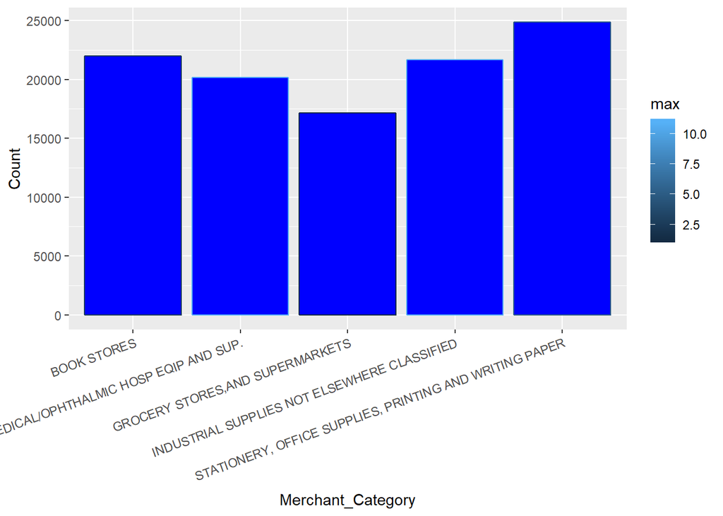

```r
#Chart
stat_by_mc_count <- stat_by_mc %>% dplyr::arrange(desc(Count))
stat_by_mc_count_temp <- stat_by_mc_count[1:5,]
ggplot(stat_by_mc_count_temp,aes(x = Merchant_Category,y = Count,colour = max)) +
  geom_bar(stat="identity", fill="blue") +
  theme(axis.text.x = element_text(angle = 20, hjust = 1))
```

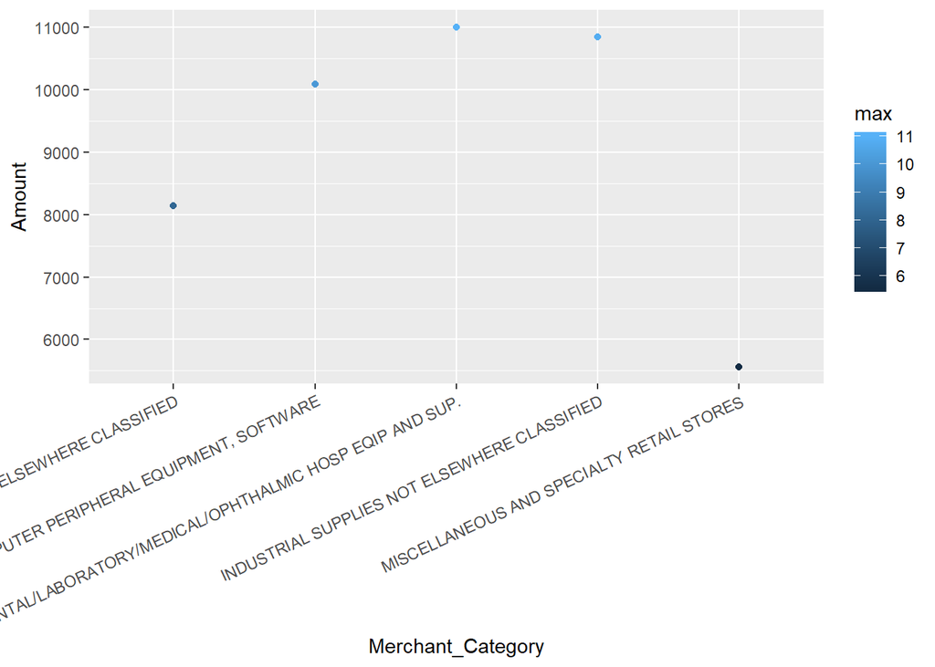

```r
stat_by_mc_amount <- stat_by_mc %>% dplyr::arrange(desc(Amount), Count)
stat_by_mc_amount_temp <- stat_by_mc_amount[1:5,]
ggplot(stat_by_mc_amount_temp,aes(x = Merchant_Category,y = Amount,colour = max)) +
  geom_point(stat="identity") +
  theme(axis.text.x = element_text(angle = 25, hjust = 1))
```

```r
#Seeing the most spent by Merchant_Category, Vendor, and Agency_Name the quarter of transaction date
ccard1 <- ccard %>%
  select(Agency_Name, Vendor, Transaction_Date, Merchant_Category, Amount, r_score)

ccard1 %>% filter(r_score ==1) %>%
  group_by(Merchant_Category, Vendor, Agency_Name)%>%
  arrange(desc(Amount/1000))
```

```
## # A tibble: 109,918 x 6
## # Groups:   Merchant_Category, Vendor, Agency_Name [36,515]
##    Agency_Name   Vendor Transaction_Date Merchant_Category   Amount r_score
##    <fct>         <fct>  <date>           <fct>                <dbl>   <dbl>
##  1 UNIV. OF OKL~ PAYME~ 2013-08-21       OTHER FEES          1.90e6       1
##  2 UNIV. OF OKL~ PAYME~ 2013-07-19       OTHER FEES          1.75e6       1
##  3 GRAND RIVER ~ MOTOR~ 2013-09-24       TELECOMMUNICATION~  3.45e5       1
##  4 EMPLOYEES BE~ PAYME~ 2013-06-13       OTHER FEES          3.43e5       1
##  5 GRAND RIVER ~ FISHN~ 2013-08-14       DETECTIVE AGENCIE~  1.51e5       1
##  6 UNIVERSITY O~ EMBAS~ 2013-08-08       EMBASSY SUITES      1.14e5       1
##  7 GRAND RIVER ~ PI   ~ 2013-09-10       COMPUTER NETWORK/~  1.08e5       1
##  8 GRAND RIVER ~ SHI C~ 2013-09-24       COMPUTERS, COMPUT~  1.04e5       1
##  9 GRAND RIVER ~ ALCAT~ 2013-07-25       BUSINESS SERVICES~ 10.00e4       1
## 10 DEPARTMENT O~ WW GR~ 2013-08-28       INDUSTRIAL SUPPLI~  9.62e4       1
## # ... with 109,908 more rows
```

```r
ccard1 %>% filter(r_score ==2) %>%
  group_by(Merchant_Category, Vendor, Agency_Name)%>%
  arrange(desc(Amount/1000))
```

```
## # A tibble: 107,396 x 6
## # Groups:   Merchant_Category, Vendor, Agency_Name [34,931]
##    Agency_Name  Vendor  Transaction_Date Merchant_Category   Amount r_score
##    <fct>        <fct>   <date>           <fct>                <dbl>   <dbl>
##  1 GRAND RIVER~ PELCO ~ 2013-10-25       COMMERCIAL EQUIPME~ 1.09e6       2
##  2 GRAND RIVER~ EMC CO~ 2013-10-03       COMPUTERS, COMPUTE~ 8.15e5       2
##  3 GRAND RIVER~ EMC CO~ 2013-10-15       COMPUTERS, COMPUTE~ 4.03e5       2
##  4 GRAND RIVER~ TK CON~ 2013-11-14       GENERAL CONTRACTOR~ 3.35e5       2
##  5 GRAND RIVER~ EMC CO~ 2013-12-23       COMPUTERS, COMPUTE~ 2.81e5       2
##  6 GRAND RIVER~ ROHN P~ 2013-11-22       COMMERCIAL EQUIPME~ 1.50e5       2
##  7 GRAND RIVER~ FISHNE~ 2013-10-22       DETECTIVE AGENCIES~ 1.44e5       2
##  8 GRAND RIVER~ CHICKA~ 2013-12-03       TELECOMMUNICATION ~ 1.32e5       2
##  9 GRAND RIVER~ EVANS ~ 2013-11-26       COMMERCIAL EQUIPME~ 1.32e5       2
## 10 GRAND RIVER~ SIEMEN~ 2013-10-17       CONSTRUCTION MATER~ 1.16e5       2
## # ... with 107,386 more rows
```

```r
ccard1 %>% filter(r_score ==3) %>%
  group_by(Merchant_Category, Vendor, Agency_Name)%>%
  arrange(desc(Amount/1000))
```

```
## # A tibble: 107,681 x 6
## # Groups:   Merchant_Category, Vendor, Agency_Name [37,664]
##    Agency_Name   Vendor  Transaction_Date Merchant_Category  Amount r_score
##    <fct>         <fct>   <date>           <fct>               <dbl>   <dbl>
##  1 GRAND RIVER ~ PELCO ~ 2014-02-28       COMMERCIAL EQUIPM~ 8.55e5       3
##  2 GRAND RIVER ~ TK CON~ 2014-03-08       GENERAL CONTRACTO~ 3.08e5       3
##  3 GRAND RIVER ~ TK CON~ 2014-02-26       GENERAL CONTRACTO~ 3.06e5       3
##  4 GRAND RIVER ~ EMC CO~ 2014-01-17       COMPUTERS, COMPUT~ 3.06e5       3
##  5 GRAND RIVER ~ TK CON~ 2014-01-28       GENERAL CONTRACTO~ 2.90e5       3
##  6 GRAND RIVER ~ FLETCH~ 2014-04-01       UTILITIES - ELECT~ 2.34e5       3
##  7 DEPARTMENT O~ NORTH ~ 2014-03-25       CHEMICALS AND ALL~ 2.27e5       3
##  8 GRAND RIVER ~ EMC CO~ 2014-02-03       COMPUTERS, COMPUT~ 1.91e5       3
##  9 OKLAHOMA MIL~ CONSTR~ 2014-01-28       GOVERNMENT SERVIC~ 1.83e5       3
## 10 DEPARTMENT O~ NORTH ~ 2014-03-11       CHEMICALS AND ALL~ 1.47e5       3
## # ... with 107,671 more rows
```

```r
ccard1 %>% filter(r_score ==4) %>%
  group_by(Merchant_Category, Vendor, Agency_Name)%>%
  arrange(desc(Amount/1000))
```

```
## # A tibble: 117,463 x 6
## # Groups:   Merchant_Category, Vendor, Agency_Name [39,858]
##    Agency_Name   Vendor  Transaction_Date Merchant_Category  Amount r_score
##    <fct>         <fct>   <date>           <fct>               <dbl>   <dbl>
##  1 GRAND RIVER ~ TK CON~ 2014-04-04       GENERAL CONTRACTO~ 3.73e5       4
##  2 DEPARTMENT O~ NORTH ~ 2014-05-12       CHEMICALS AND ALL~ 3.48e5       4
##  3 GRAND RIVER ~ FLETCH~ 2014-04-17       UTILITIES - ELECT~ 2.72e5       4
##  4 GRAND RIVER ~ TK CON~ 2014-05-02       GENERAL CONTRACTO~ 2.24e5       4
##  5 GRAND RIVER ~ FLETCH~ 2014-04-17       UTILITIES - ELECT~ 1.56e5       4
##  6 DEPARTMENT O~ NORTH ~ 2014-04-14       CHEMICALS AND ALL~ 1.44e5       4
##  7 GRAND RIVER ~ EVANS ~ 2014-06-20       COMMERCIAL EQUIPM~ 1.33e5       4
##  8 GRAND RIVER ~ FLETCH~ 2014-05-09       UTILITIES - ELECT~ 1.12e5       4
##  9 GRAND RIVER ~ FLETCH~ 2014-06-04       UTILITIES - ELECT~ 1.03e5       4
## 10 GRAND RIVER ~ CONTIN~ 2014-04-14       INDUSTRIAL SUPPLI~ 8.30e4       4
## # ... with 117,453 more rows
```

Conclusion:

There are clear patterns that arise from the type of purchases that are made. For example, some of the logical conclusions that stick out are:

- Computers and software were the third most in regards to the amount paid however they were not bought as many time
- Book stores and stationary/ office supplies tend to have a lot of purchases but not a lot of money spent in them

Observations that do not seem to align with logical assumptions:

- Medical proedcures like Dental are high in terms of count and amount. While it makes sense that there would be a lot of money spent on medical procedures, logic would dictate that these elements would be lower in the amount of times that they were bought.
- Grand River Dam had a very large uptick in transactions and was responsible for the most expensive purchases starting in the 2nd quarter through the end of the dataset With this information and the groupings provided above, there should be a cross-validation of these three features (and the time of their purchases) with the indipendant variable of the dataset.

Lead:

Next we will look at the consumer side of the equation. We will look at the last name, and then combine the first initial to see if there is a significant difference when comparing the the more specific ‘Full_Name’ metric. This is an important feature as it will allow us to pinpoint a fraud case when it occurs from the consumer side. Its important to note that applying this approach on a grander scale in operation has some ethical risks. These risks arise from the fact that names, particularly for that of individuals, can have correlations with certain types of purchases and actions based on their culture or other factors. Due to this risk, applying models to a feature like the name of the consumer can sometimes garner significance behind when there isnt much of it.

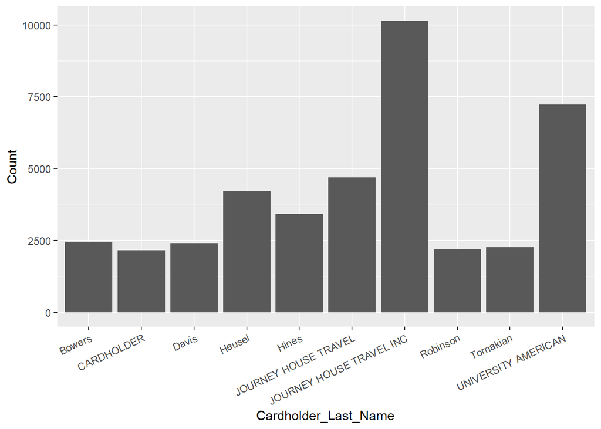

```r
#Grouping by last name
stat_by_lastname <- ccard %>% group_by(Cardholder_Last_Name) %>%
  summarise(Count = n(),
            Amount = sum(ccard$Amount/1000),
            mean = mean(ccard$Amount/1000),
            min = min(ccard$Amount/1000),
            max = max(ccard$Amount/1000)
  ) %>%
  arrange(desc(Count))%>% ungroup()

lastname_temp <-stat_by_lastname[1:10,]
ggplot(lastname_temp,aes(x = Cardholder_Last_Name,y = Count)) +
  geom_bar(stat="identity") +
  theme(axis.text.x = element_text(angle = 25, hjust = 1))
```

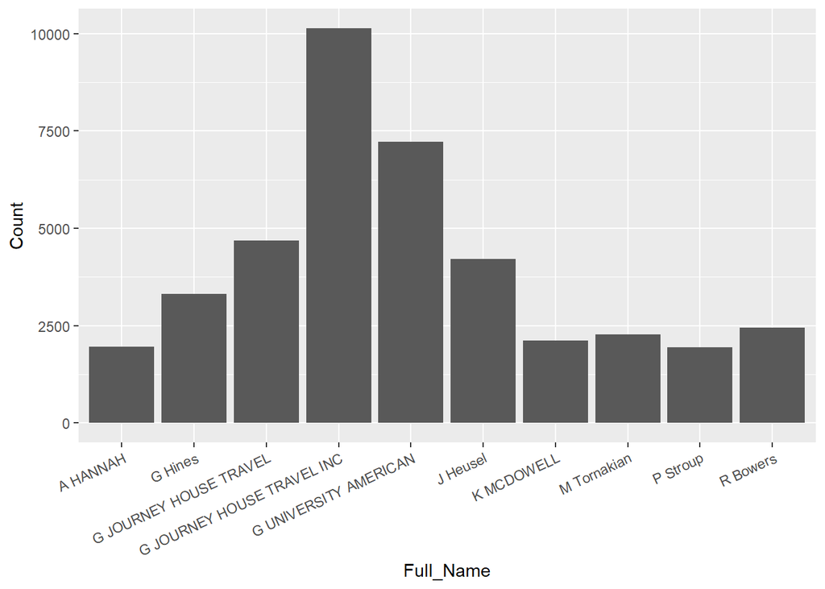

```r
#Combining last name with first initial
Full_Name <-paste0(as.character(ccard$Cardholder_First_Initial)," ", as.character(ccard$Cardholder_Last_Name))
ccard <- cbind(ccard, Full_Name)

stat_by_name <- ccard %>% group_by(Full_Name) %>%
  summarise(Count = n(),
            Amount = sum(ccard$Amount/1000),
            mean = mean(ccard$Amount/1000),
            min = min(ccard$Amount/1000),
            max = max(ccard$Amount/1000)
  ) %>%
  arrange(desc(Count))%>% ungroup()

name_temp <-stat_by_name[1:10,]
ggplot(name_temp,aes(x = Full_Name,y = Count)) +
  geom_bar(stat="identity") +
  theme(axis.text.x = element_text(angle = 25, hjust = 1))
```

```r
#Looking at name per quarter of date purchased
ccard2 <- ccard %>%
  select(Full_Name, Vendor, Merchant_Category, Agency_Name, Amount, r_score)

ccard2 %>% filter(r_score ==1) %>%
  group_by(Full_Name)%>%
  arrange(desc(Amount/1000))
```

```
## # A tibble: 109,918 x 6
## # Groups:   Full_Name [4,244]
##    Full_Name  Vendor   Merchant_Category     Agency_Name     Amount r_score
##    <fct>      <fct>    <fct>                 <fct>            <dbl>   <dbl>
##  1 7 77000    PAYMENT~ OTHER FEES            UNIV. OF OKLA~  1.90e6       1
##  2 7 77000    PAYMENT~ OTHER FEES            UNIV. OF OKLA~  1.75e6       1
##  3 e Cardhol~ MOTOROL~ TELECOMMUNICATION EQ~ GRAND RIVER D~  3.45e5       1
##  4 8 81500    PAYMENT~ OTHER FEES            EMPLOYEES BEN~  3.43e5       1
##  5 e Cardhol~ FISHNET~ DETECTIVE AGENCIES,P~ GRAND RIVER D~  1.51e5       1
##  6 P CANTRELL EMBASSY~ EMBASSY SUITES        UNIVERSITY OF~  1.14e5       1
##  7 G Hunter   PI   PR~ COMPUTER NETWORK/INF~ GRAND RIVER D~  1.08e5       1
##  8 G Hunter   SHI CORP COMPUTERS, COMPUTER ~ GRAND RIVER D~  1.04e5       1
##  9 e Cardhol~ ALCATEL~ BUSINESS SERVICES NO~ GRAND RIVER D~ 10.00e4       1
## 10 C Bowlin   WW GRAI~ INDUSTRIAL SUPPLIES ~ DEPARTMENT OF~  9.62e4       1
## # ... with 109,908 more rows
```

```r
ccard2 %>% filter(r_score ==2) %>%
  group_by(Full_Name)%>%
  arrange(desc(Amount/1000))
```

```
## # A tibble: 107,396 x 6
## # Groups:   Full_Name [4,223]
##    Full_Name  Vendor    Merchant_Category       Agency_Name  Amount r_score
##    <fct>      <fct>     <fct>                   <fct>         <dbl>   <dbl>
##  1 e Cardhol~ PELCO ST~ COMMERCIAL EQUIPMENT, ~ GRAND RIVER~ 1.09e6       2
##  2 e Cardhol~ EMC CORP~ COMPUTERS, COMPUTER PE~ GRAND RIVER~ 8.15e5       2
##  3 e Cardhol~ EMC CORP~ COMPUTERS, COMPUTER PE~ GRAND RIVER~ 4.03e5       2
##  4 e Cardhol~ TK CONST~ GENERAL CONTRACTORS-RE~ GRAND RIVER~ 3.35e5       2
##  5 e Cardhol~ EMC CORP~ COMPUTERS, COMPUTER PE~ GRAND RIVER~ 2.81e5       2
##  6 e Cardhol~ ROHN PRO~ COMMERCIAL EQUIPMENT, ~ GRAND RIVER~ 1.50e5       2
##  7 e Cardhol~ FISHNET ~ DETECTIVE AGENCIES,PRO~ GRAND RIVER~ 1.44e5       2
##  8 G Hunter   CHICKASA~ TELECOMMUNICATION EQUI~ GRAND RIVER~ 1.32e5       2
##  9 e Cardhol~ EVANS EN~ COMMERCIAL EQUIPMENT, ~ GRAND RIVER~ 1.32e5       2
## 10 e Cardhol~ SIEMENS ~ CONSTRUCTION MATERIALS~ GRAND RIVER~ 1.16e5       2
## # ... with 107,386 more rows
```

```r
ccard2 %>% filter(r_score ==3) %>%
  group_by(Full_Name)%>%
  arrange(desc(Amount/1000))
```

```
## # A tibble: 107,681 x 6
## # Groups:   Full_Name [4,164]
##    Full_Name  Vendor    Merchant_Category      Agency_Name   Amount r_score
##    <fct>      <fct>     <fct>                  <fct>          <dbl>   <dbl>
##  1 e Cardhol~ PELCO ST~ COMMERCIAL EQUIPMENT,~ GRAND RIVER ~ 8.55e5       3
##  2 e Cardhol~ TK CONST~ GENERAL CONTRACTORS-R~ GRAND RIVER ~ 3.08e5       3
##  3 e Cardhol~ TK CONST~ GENERAL CONTRACTORS-R~ GRAND RIVER ~ 3.06e5       3
##  4 e Cardhol~ EMC CORP~ COMPUTERS, COMPUTER P~ GRAND RIVER ~ 3.06e5       3
##  5 e Cardhol~ TK CONST~ GENERAL CONTRACTORS-R~ GRAND RIVER ~ 2.90e5       3
##  6 e Cardhol~ FLETCHER~ UTILITIES - ELECTRIC,~ GRAND RIVER ~ 2.34e5       3
##  7 C Johnson  NORTH AM~ CHEMICALS AND ALLIED ~ DEPARTMENT O~ 2.27e5       3
##  8 e Cardhol~ EMC CORP~ COMPUTERS, COMPUTER P~ GRAND RIVER ~ 1.91e5       3
##  9 J MALLOY   CONSTRUC~ GOVERNMENT SERVICES--~ OKLAHOMA MIL~ 1.83e5       3
## 10 C Johnson  NORTH AM~ CHEMICALS AND ALLIED ~ DEPARTMENT O~ 1.47e5       3
## # ... with 107,671 more rows
```

```r
ccard2 %>% filter(r_score ==4) %>%
  group_by(Full_Name)%>%
  arrange(desc(Amount/1000))
```

```
## # A tibble: 117,463 x 6
## # Groups:   Full_Name [4,477]
##    Full_Name  Vendor    Merchant_Category      Agency_Name   Amount r_score
##    <fct>      <fct>     <fct>                  <fct>          <dbl>   <dbl>
##  1 e Cardhol~ TK CONST~ GENERAL CONTRACTORS-R~ GRAND RIVER ~ 3.73e5       4
##  2 C Johnson  NORTH AM~ CHEMICALS AND ALLIED ~ DEPARTMENT O~ 3.48e5       4
##  3 e Cardhol~ FLETCHER~ UTILITIES - ELECTRIC,~ GRAND RIVER ~ 2.72e5       4
##  4 e Cardhol~ TK CONST~ GENERAL CONTRACTORS-R~ GRAND RIVER ~ 2.24e5       4
##  5 e Cardhol~ FLETCHER~ UTILITIES - ELECTRIC,~ GRAND RIVER ~ 1.56e5       4
##  6 C Johnson  NORTH AM~ CHEMICALS AND ALLIED ~ DEPARTMENT O~ 1.44e5       4
##  7 e Cardhol~ EVANS EN~ COMMERCIAL EQUIPMENT,~ GRAND RIVER ~ 1.33e5       4
##  8 e Cardhol~ FLETCHER~ UTILITIES - ELECTRIC,~ GRAND RIVER ~ 1.12e5       4
##  9 e Cardhol~ FLETCHER~ UTILITIES - ELECTRIC,~ GRAND RIVER ~ 1.03e5       4
## 10 e Cardhol~ CONTINEN~ INDUSTRIAL SUPPLIES N~ GRAND RIVER ~ 8.30e4       4
## # ... with 117,453 more rows
```

Conclusion:

There did not seem to be a lot of inference that could be gleaned from looking at the name data. First, the count of how many purchases were done by customer tended to lean towards corporations in the top three (Specifically Jurney Huse Travel and American University), with individual buyers coming in afterwards. Combining the first initial with the last name would help in being more specific to accumulate the transactions. One curious tendency which came out was the PELCO Structural LLC was consistently amongst the most amount paid. I did have trouble with accumulating the amount figure by the full name variable. It would have been useful to cross reference the count to Amount variable when it comes to the name variable. Nonetheless, this variables will be useful in specying cases of fraud once variables are further broken down and more understood.

Lead:

Next we will focus on the vendors specifically and will cross reference key purchase data in order to look at this category on a per transaction, absolute, and frequency of transaction levels. The key in identifying fraud in credit card is to have a good clustering of tendencies for buyer and seller side. Therefore being able to get an outlook at vendors from different angels will allow us to tie these variables to specific buyers.

```r
###Monetary- Vendor
stat_by_vendor <- ccard %>% group_by(Vendor) %>%
  summarise(Count = n(),
            Amount = sum(Amount/1000),
            mean = mean(Amount/1000),
            min = min(Amount/1000),
            max = max(Amount/1000)
  ) %>%
  arrange(desc(Amount)) %>% ungroup()
stat_by_vendor
```

```
## # A tibble: 86,729 x 6
##    Vendor                   Count Amount  mean   min   max
##    <fct>                    <int>  <dbl> <dbl> <dbl> <dbl>
##  1 WW GRAINGER              12076  5089.  5.09  5.09  5.09
##  2 PAYMENT ADJUSTMENT           6  4062.  4.06  4.06  4.06
##  3 DMI  DELL K-12/GOVT       1266  3458.  3.46  3.46  3.46
##  4 DMI  DELL HIGHER EDUC     2029  2641.  2.64  2.64  2.64
##  5 EMC CORPORATION              8  2155.  2.15  2.15  2.15
##  6 SOUTH CENTRAL INDUSTRIES  1338  2028.  2.03  2.03  2.03
##  7 PELCO STRUCTURAL LLC         2  1945.  1.94  1.94  1.94
##  8 STAPLES                  14842  1913.  1.91  1.91  1.91
##  9 TK CONSTRUCTIO US LLC        7  1895.  1.89  1.89  1.89
## 10 MCKESSON MEDICAL SUPPLY   2491  1411.  1.41  1.41  1.41
## # ... with 86,719 more rows
```

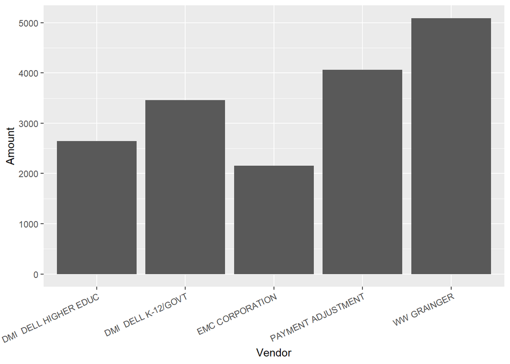

```r
#Chart of top 5 Vendors
vendor_temp1<- stat_by_vendor[1:5,]
ggplot(vendor_temp1,aes(x = Vendor,y = Amount)) +
  geom_bar(stat="identity") +
  theme(axis.text.x = element_text(angle = 25, hjust = 1))
```

```r
stat_by_vendor2 <- ccard %>% group_by(Vendor) %>%
  summarise(Count = n(),
            Amount = sum(Amount/1000)
  ) %>%
  arrange(desc(Count)) %>% ungroup()
stat_by_vendor2
```

```
## # A tibble: 86,729 x 3
##    Vendor                    Count Amount
##    <fct>                     <int>  <dbl>
##  1 STAPLES                   14842 1913.
##  2 AMAZON MKTPLACE PMTS      12197 1293.
##  3 WW GRAINGER               12076 5089.
##  4 Amazon.com                10766 1398.
##  5 BILL WARREN OFFICE PRODUC  4479  590.
##  6 LOWES #00241               4231  377.
##  7 VWR INTERNATIONAL INC      3912 1025.
##  8 AT&T BILL PAYMENT          3064  967.
##  9 AIRGAS CENTRAL             2682  320.
## 10 AT&T DATA                  2622   74.3
## # ... with 86,719 more rows
```

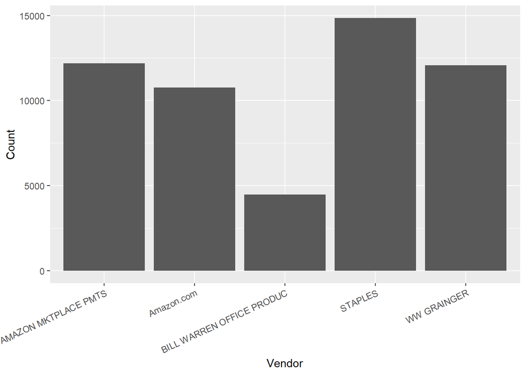

```r
vendor_temp2<- stat_by_vendor2[1:5,]
ggplot(vendor_temp2,aes(x = Vendor,y = Count)) +
  geom_bar(stat="identity") +
  theme(axis.text.x = element_text(angle = 25, hjust = 1))
```

```r
#Adding variable amount per transactions (Not counted in 1000's)
stat_by_vendor3 <- ccard %>% group_by(Vendor) %>%
  summarise(Count = n(),
            Amount = sum(Amount)
  ) %>%
  mutate(avg_Purchase = Amount/Count)%>%
  arrange(desc(avg_Purchase)) %>% ungroup()

stat_by_vendor3
```

```
## # A tibble: 86,729 x 4
##    Vendor                  Count   Amount avg_Purchase
##    <fct>                   <int>    <dbl>        <dbl>
##  1 PELCO STRUCTURAL LLC        2 1944523       972262.
##  2 PAYMENT ADJUSTMENT          6 4061761.      676960.
##  3 TK CONSTRUCTIO US LLC       7 1894685.      270669.
##  4 EMC CORPORATION             8 2154665.      269333.
##  5 ROHN PRODUCTS LLC           1  149500       149500
##  6 JD C&F CO DIRECT SALES      1   75394.       75394.
##  7 INVITROGEN 23538472         1   65883.       65883.
##  8 BK MEDICAL SYSTEMS INC.     1   63959        63959
##  9 FISHNET SECURITY            6  373981.       62330.
## 10 MECO INC                    1   57835.       57835.
## # ... with 86,719 more rows
```

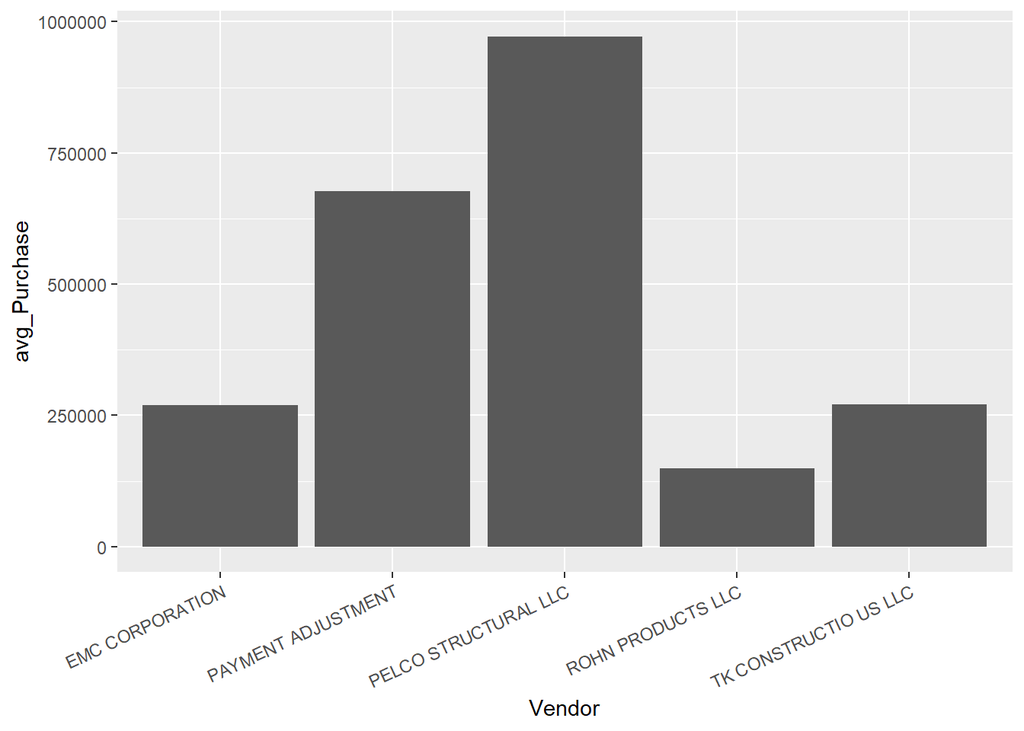

```r
vendor_temp3<- stat_by_vendor3[1:5,]
ggplot(vendor_temp3,aes(x = Vendor,y = avg_Purchase)) +
  geom_bar(stat="identity") +
  theme(axis.text.x = element_text(angle = 25, hjust = 1))
```

```r
#Grouping by Vendor and Merhcant
stat_by_vendor4 <- ccard %>% group_by(Vendor, Agency_Name) %>%
  summarise(Count = n(),
            Amount = sum(Amount)
  ) %>%
  mutate(avg_Purchase = Amount/Count)%>% ungroup()
stat_by_vendor4
```

```
## # A tibble: 111,917 x 5
##    Vendor             Agency_Name                 Count Amount avg_Purchase
##    <fct>              <fct>                       <int>  <dbl>        <dbl>
##  1 #1 PARTY SUPPLIES  DEPARTMENT OF VETERANS AFF~     1  347.         347.
##  2 #101 BLUE CORN     UNIVERSITY OF OKLAHOMA          1  379.         379.
##  3 #15 VS             ROSE STATE COLEGE               1   51.9         51.9
##  4 #15 VS             UNIV. OF OKLA. HEALTH SCIE~     1   65.0         65.0
##  5 #17 VS             UNIVERSITY OF OKLAHOMA          1  129.         129.
##  6 #18 VS             UNIVERSITY OF OKLAHOMA          5  689.         138.
##  7 #22 PREFERRED PUM~ DEPARTMENT OF TOURISM AND ~     3 1686.         562.
##  8 #41 BRIO COUNTRY ~ OKLAHOMA STATE UNIVERSITY       1  920.         920.
##  9 #44 BRAVO| MEMORI~ DEPARTMENT OF PUBLIC SAFETY     7  227.          32.5
## 10 00000000000000000~ UNIVERSITY OF OKLAHOMA          1   55.2         55.2
## # ... with 111,907 more rows
```

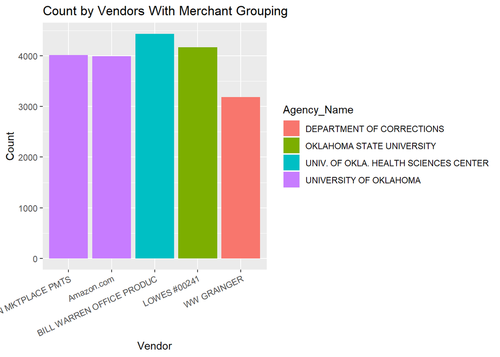

```r
#Vendor and Merchant by count
stat_by_vendor4_Count <- stat_by_vendor4 %>% arrange(desc(Count))
count_temp <- stat_by_vendor4_Count[1:5,]
ggplot(count_temp,aes(x = Vendor,y = Count, fill = Agency_Name)) +
  geom_bar(stat="identity") +
  theme(axis.text.x = element_text(angle = 25, hjust = 1))+
  ggtitle('Count by Vendors With Merchant Grouping')
```

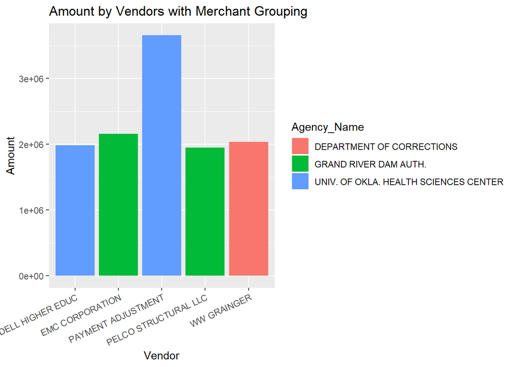

```r
#Vendor and Merchant by Amount
stat_by_vendor4_Amount <- stat_by_vendor4 %>% arrange(desc(Amount))
amount_temp <- stat_by_vendor4_Amount[1:5,]
ggplot(amount_temp,aes(x = Vendor,y = Amount, fill = Agency_Name)) +
  geom_bar(stat="identity") +
  theme(axis.text.x = element_text(angle = 25, hjust = 1))+
  ggtitle('Amount by Vendors with Merchant Grouping')
```

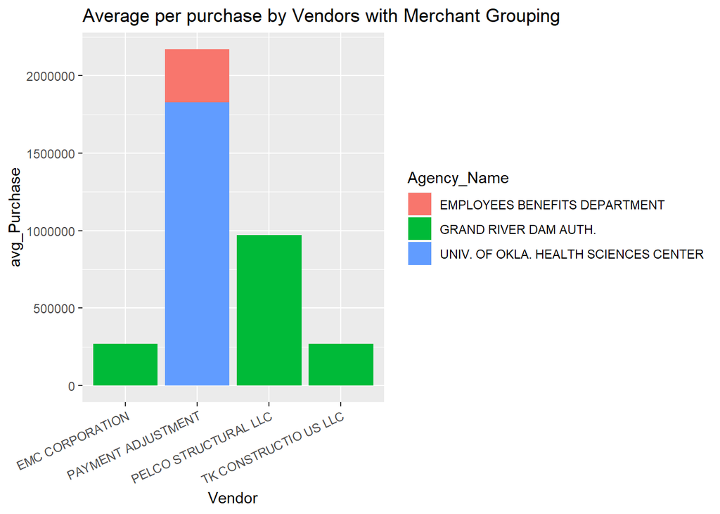

```r
#Average amount by Vendor and Merchant Grouping
stat_by_vendor4_AvgPur <- stat_by_vendor4 %>% arrange(desc(avg_Purchase))
avgpur_temp <- stat_by_vendor4_AvgPur[1:5,]
ggplot(avgpur_temp,aes(x = Vendor, y = avg_Purchase, fill = Agency_Name)) +
  geom_bar(stat="identity") +
  theme(axis.text.x = element_text(angle = 25, hjust = 1))+
  ggtitle('Average per purchase by Vendors with Merchant Grouping')
```

Conclusion:

By taking a look at vendors and their corresponding consumers we are able to glean important details in regards to sizes and tendencies of transactions. The variables were looked at individually by vendor and then collectively by the grouping of Vendor and Agency_Name. The immediate outliers were the adjustment payments that were paid by medically services and then the very large amount of transactions that occured by some vendors.

Logical observations:

## Final Conclusion:

- Time Based Variables: We were able to outline the timeline of transactions of this dataset while identifying spikes in major transactions amount during an otherwise consistent count of purchases. In addition, being able to categorize timelines per quarter of the timeline of the dataset. Finally, having a variable showing the difference in time from the most recent transaction will be useful in identifying anomalies in purchasing by customers.
- Frequency of transactions: We looked at the Merchant Category and were able to identify the anomalies when it comes to logical and illogical pairings of transactions. This was then couple with looking at the name variables to align the most common purchasers as well as the highest spenders per transaction. Being able to group the tendencies of frequency and size of a purchase to a specific buyer will allow us to identify the anomalies which could signal fraud much more efficiently.
- Monetary value and realtionship to Vendors/ Custmers: We focused on the vendor side to give us an outline of who the sellers are in this dataset and how the tendency of their transactions look. Adding the average purchase and comapring it to the number of transactions and total amount spent gave us an important perspective. Specifically, the per transaction purchases tended to cluster around large conglomorate e-commerce customers while the largest individual purchasers were generally from corporations. Nonetheless, the identification of a buyer grouped and compared with these factors will give us the estimates needed to be able to more confidently identify fraud.

Some of the variables that I hope to include in more detail once we start creating predictive models are description, and the type of transaction (which this dataset did not have). These elements, including the ones discussed here such as time, frequency, amount purchased, and the categorization of buyers/ sellers will be excellent predictors of credit card fraud.